# Nutrient hotspot maps — post-Kona low storm

# Stoichiometric fingerprints

Did all islands produce the same kind of runoff, or does each island have its own chemical identity? The ratios of nutrients to each other — nitrogen to phosphorus (N:P) and silica to nitrogen (Si:N) — act like a fingerprint that reveals where nutrients came from. Ocean plankton maintain nitrogen and phosphorus in a fairly fixed ratio of 16:1 (the Redfield ratio). Below 16 means unusual phosphorus enrichment, pointing to a cesspool or wastewater source. Above 1 for Si:N means silica-rich volcanic rock weathering is dominant. The four islands show distinctly different ratios, meaning the storm flushed island-specific chemical fingerprints — not a single uniform nutrient pulse.

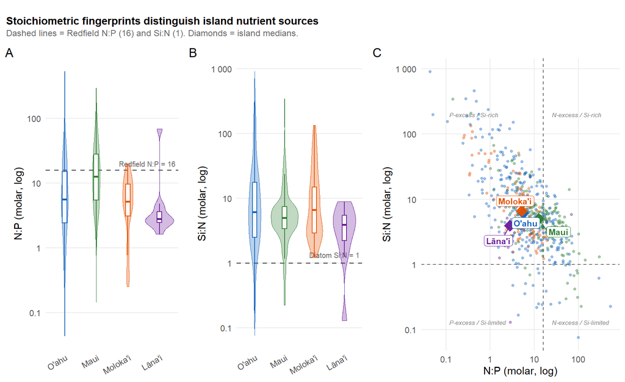

(A) Nitrogen-to-phosphorus ratio (N:P) by island. Ocean plankton normally maintain N:P near 16:1 (dashed line) — below 16 means there is more phosphorus than biology expects, pointing to wastewater or cesspool inputs. All four islands are below 16. (B) Silica-to-nitrogen ratio (Si:N). Values above 1 (dashed) indicate the water is carrying more dissolved rock material (silica from volcanic weathering) than nitrogen — the signature of storm runoff over Hawaiian terrain. (C) Both ratios together, with island medians shown as diamonds. All islands sit in the phosphorus-excess, silica-rich corner. Maui’s ratio is closest to the biological reference line, suggesting its runoff has more agricultural nitrogen (which drives N:P up toward 16). Oʻahu and Molokaʻi are farther into the phosphorus-excess zone, consistent with denser cesspool infrastructure.

```r
ratios <- chem |>
  filter(!is.na(island), NO3NO2 > 0, PO4 > 0, SiO2 > 0) |>
  mutate(
    NP     = NO3NO2 / PO4,
    SiN    = SiO2   / NO3NO2,
    island = factor(island, levels = c("O'ahu", "Maui", "Moloka'i", "Lāna'i"))
  ) |>
  filter(!is.na(island))

violin_theme <- theme_minimal(base_size = 11) +
  theme(panel.grid.minor = element_blank(), panel.grid.major.x = element_blank(),
        axis.title.x = element_blank(), axis.text.x = element_text(angle = 30, hjust = 1),
        legend.position = "none")

pNP_s <- ggplot(ratios, aes(x = island, y = NP, fill = island, color = island)) +
  geom_hline(yintercept = 16, linetype = "dashed", color = "gray40", linewidth = 0.6) +
  annotate("text", x = Inf, y = 20, label = "Redfield N:P = 16",
           size = 2.7, color = "gray40", hjust = 1.05) +
  geom_violin(alpha = 0.30, linewidth = 0.35, trim = TRUE) +
  geom_boxplot(width = 0.15, outliers = FALSE, fill = "white", linewidth = 0.45, alpha = 0.9) +
  scale_fill_manual(values = island_pal) + scale_color_manual(values = island_pal) +
  scale_y_log10(breaks = c(0.1, 1, 10, 100),
                labels = scales::label_number(drop0trailing = TRUE)) +
  labs(y = "N:P (molar, log)", tag = "A") + violin_theme

pSiN_s <- ggplot(ratios, aes(x = island, y = SiN, fill = island, color = island)) +
  geom_hline(yintercept = 1, linetype = "dashed", color = "gray40", linewidth = 0.6) +
  annotate("text", x = Inf, y = 1.35, label = "Diatom Si:N = 1",
           size = 2.7, color = "gray40", hjust = 1.05) +
  geom_violin(alpha = 0.30, linewidth = 0.35, trim = TRUE) +
  geom_boxplot(width = 0.15, outliers = FALSE, fill = "white", linewidth = 0.45, alpha = 0.9) +
  scale_fill_manual(values = island_pal) + scale_color_manual(values = island_pal) +
  scale_y_log10(breaks = c(0.1, 1, 10, 100, 1000),
                labels = scales::label_number(drop0trailing = TRUE)) +
  labs(y = "Si:N (molar, log)", tag = "B") + violin_theme

centroids_s <- ratios |>
  group_by(island) |>
  summarise(NP = median(NP, na.rm = TRUE), SiN = median(SiN, na.rm = TRUE), .groups = "drop")

pScatter_s <- ggplot(ratios, aes(x = NP, y = SiN, color = island)) +
  geom_vline(xintercept = 16, linetype = "dashed", color = "gray40", linewidth = 0.5) +
  geom_hline(yintercept = 1,  linetype = "dashed", color = "gray40", linewidth = 0.5) +
  annotate("text", x = 0.12, y = 0.13, label = "P-excess / Si-limited",
           size = 2.3, color = "gray50", hjust = 0, fontface = "italic") +
  annotate("text", x = 25,   y = 0.13, label = "N-excess / Si-limited",
           size = 2.3, color = "gray50", hjust = 0, fontface = "italic") +
  annotate("text", x = 0.12, y = 200,  label = "P-excess / Si-rich",
           size = 2.3, color = "gray50", hjust = 0, fontface = "italic") +
  annotate("text", x = 25,   y = 200,  label = "N-excess / Si-rich",
           size = 2.3, color = "gray50", hjust = 0, fontface = "italic") +
  geom_point(size = 1.1, alpha = 0.4) +
  geom_point(data = centroids_s, size = 5.5, shape = 18, alpha = 0.95) +
  ggrepel::geom_label_repel(
    data = centroids_s, aes(label = island),
    size = 3, fontface = "bold", label.padding = unit(0.15, "lines"),
    label.size = 0.2, show.legend = FALSE
  ) +
  scale_color_manual(values = island_pal, name = NULL) +
  scale_x_log10(breaks = c(0.1, 1, 10, 100),
                labels = scales::label_number(drop0trailing = TRUE)) +
  scale_y_log10(breaks = c(0.1, 1, 10, 100, 1000),
                labels = scales::label_number(drop0trailing = TRUE)) +
  labs(x = "N:P (molar, log)", y = "Si:N (molar, log)", tag = "C") +
  theme_minimal(base_size = 11) +
  theme(panel.grid.minor = element_blank(), legend.position = "none")

title_row_s <- ggdraw() +
  draw_label("Stoichiometric fingerprints distinguish island nutrient sources",
             fontface = "bold", size = 11, x = 0.01, hjust = 0) +
  draw_label("Dashed lines = Redfield N:P (16) and Si:N (1). Diamonds = island medians.",
             color = "gray40", size = 9, x = 0.01, y = 0.2, hjust = 0)

plot_grid(
  title_row_s,
  plot_grid(pNP_s, pSiN_s, pScatter_s, nrow = 1, rel_widths = c(1, 1, 1.4)),
  ncol = 1, rel_heights = c(0.12, 1)
)
```

Maui’s N:P ratio (median 12.6) is noticeably higher than Oʻahu (5.6) and Molokaʻi (5.2). That gap is consistent with East Maui’s large farming areas contributing extra nitrogen — bumping the N:P ratio closer to the 16:1 biological baseline even while still remaining phosphorus-enriched. Every island has Si:N ratios well above 1, meaning volcanic rock dissolution is a dominant contributor across the board — an expected signature of Hawaiian watersheds. Each island’s runoff tells a different story about its land use.